# NOAA Earthquake data Visualization

D. P. Tweed

2019-11-03

# Introduction

The objective of this package is to:

1. Efficently process the data
2. Provide easy to use function for dedicated explorattory analysis

## Data source

National Geophysical Data Center / World Data Service (NGDC/WDS): [Significant Earthquake Database. National Geophysical Data Center, NOAA. (doi:10.7289/V5TD9V7K)](https://data.nodc.noaa.gov/cgi-bin/iso?id=gov.noaa.ngdc.mgg.hazards:G012153)

The data is incorporated into this package in file /private/var/folders/_9/q5m6d30n5n9296mc_x5l2gqw0000gn/T/RtmpQ9Oh6W/temp_libpath10ff421ed3b17/NOAAsignifEarthQuakes/extdata/signif.txt

## Loading the package

```r
library(NOAAsignifEarthQuakes)
# additionally for piping
library(magrittr)
```

| Function | Data Processing | Timeline visualization | Map visualization |
| --- | --- | --- | --- |
| eq_build_date | ✔ |  |  |
| eq_build_location | ✔ |  |  |
| eq_clean_data | ✔ |  |  |
| load_NOAA_db | ✔ |  |  |
| eq_legend_timeline |  | ✔ |  |
| geom_timeline |  | ✔ |  |
| geom_timeline_label |  | ✔ |  |
| timeline_data |  | ✔ |  |
| eq_create_label |  |  | ✔ |
| eq_map |  |  | ✔ |

# Reading and cleaning the data

We use 2 main function to read and clean the data: 1. `load_NOAA_db` : read the raw NOAA file 1. `eq_clean_data`: process the resulting data frame using support finctions: * `eq_build_date`: to create the date feature from input year, month and day * `eq_build_locaton`: to proccess the location feature in a more human readable way

## Reading the data: `load_NOAA_db`

We odtain a table with 47 features and 6066 observations. We describe the schema of the raw data in detail in the appendix.

## Processing the data

### Processing dates: `eq_build_date`

We simply take the `YEAR`, `MONTH` and `DAY` features in order to create the date feature. We demonstrate on the first 5 and last % raw of the original data building a valid date feature named `clean_date`

```r
knitr::kable(
head(noaa_raw,5) %>%
  dplyr::select("DAY","MONTH","YEAR") %>%
  dplyr::mutate(clean_date=eq_build_date(.))
)
```

| DAY | MONTH | YEAR | clean_date |
| --- | --- | --- | --- |
| NA | NA | -2150 | -2150-01-01 |
| NA | NA | -2000 | -2000-01-01 |
| NA | NA | -2000 | -2000-01-01 |
| NA | NA | -1610 | -1610-01-01 |
| NA | NA | -1566 | -1566-01-01 |

```r
knitr::kable(
tail(noaa_raw,5) %>%
  dplyr::select("DAY","MONTH","YEAR") %>%
  dplyr::mutate(clean_date=eq_build_date(.))
)
```

| DAY | MONTH | YEAR | clean_date |
| --- | --- | --- | --- |
| 12 | 9 | 2018 | 2018-09-12 |
| 28 | 9 | 2018 | 2018-09-28 |
| 7 | 10 | 2018 | 2018-10-07 |
| 10 | 10 | 2018 | 2018-10-10 |
| 25 | 10 | 2018 | 2018-10-25 |

### Processing locations: `eq_build_location`

This function consists on: * Removing the Country * Extra location information within parethesis * Correct white spaces * Switch to Title case

```r
knitr::kable(
head(noaa_raw,10) %>%
  dplyr::select("LOCATION_NAME") %>%
  dplyr::mutate(clean_location=eq_build_location(.))
)
```

| LOCATION_NAME | clean_location |
| --- | --- |
| JORDAN: BAB-A-DARAA,AL-KARAK | Bab-A-Daraa, Al-Karak |
| TURKMENISTAN: W | W |
| SYRIA: UGARIT | Ugarit |
| GREECE: THERA ISLAND (SANTORINI) | Thera Island |
| ISRAEL: ARIHA (JERICHO) | Ariha |
| ITALY: LACUS CIMINI | Lacus Cimini |
| SYRIAN COASTS | Syrian Coasts |
| ISRAEL: ARIHA (JERICHO) | Ariha |
| JORDAN: SW: TIMNA COPPER MINES | Timna Copper Mines |
| ISRAEL: JERUSALEM | Jerusalem |

### Cleaning the data; `eq_clean_data`

Mainly this funcions consist of processing existing the features with the helper function above and select features reducing the raw data to 7 features but still 6066 observations:

1. **DATE** : date of the earthqukes event
2. **COUNTRY** : country where the earthquake occured
3. **LOCATION_NAME** : location of the earthquake
4. **LONGITUDE** : Longitude coordinate of the Earthquake epicenter
5. **LATITUDE** : Latitude coordinate of the Earthquake epicenter
6. **DEATHS** : Total number of fatalities caused by the earthquakes
7. **MAG** : Equivelent Richter scale Magnitude

```r
noaa_clean <- eq_clean_data(noaa_raw)
```

| DATE | COUNTRY | LOCATION_NAME | LONGITUDE | LATITUDE | DEATHS | MAG |
| --- | --- | --- | --- | --- | --- | --- |
| 2018-08-29 | NEW CALEDONIA | Loyalty Islands | 170.050 | -22.066 | NA | 7.1 |
| 2018-09-05 | JAPAN | Hokkaido | 141.933 | 42.671 | 44 | 6.6 |
| 2018-09-06 | FIJI | Fiji Islands | 179.332 | -18.494 | NA | 7.8 |
| 2018-09-07 | IRAN | Kerman | 59.315 | 28.342 | 1 | 5.5 |
| 2018-09-08 | CHINA | Mojiang Hani | 101.552 | 23.332 | NA | 5.6 |
| 2018-09-12 | INDIA | West Bengal | 90.165 | 26.374 | 1 | 5.3 |
| 2018-09-28 | INDONESIA | Sulawesi | 119.840 | -0.178 | 2256 | 7.5 |
| 2018-10-07 | HAITI | Port-Dex-Paix | -72.975 | 20.041 | 18 | 5.9 |
| 2018-10-10 | INDONESIA | Madura Island, Java | 114.453 | -7.456 | 4 | 6.0 |
| 2018-10-25 | GREECE | Zakynthos, Strofades | 20.563 | 37.506 | NA | 6.8 |

# Building a Timeline

## Filtering the data with `timeline_data`

This function consist on preparing the data prioir to building the timeline. It enable to:

1. Drops features unnecessary to the timeline (e.g. `LATITUDE` and `LONGITUDE`)
2. filter within a date range specified with keyword `dmin` and `dmax`
3. filter 1 or several countries with keyword `countries`
4. Additionnaly it create a feature `MAG_RANK` giving the rank order of earthquake by country in descreasing order of Magnitude

```r
filt_noaa <- noaa_clean %>%
  timeline_data(dmin='2010-01-01',dmax='2011-01-01',countries=c("USA","China"))
```

| DATE | COUNTRY | LOCATION_NAME | DEATHS | MAG | MAG_RANK |
| --- | --- | --- | --- | --- | --- |
| 2010-01-10 | USA | Off Coast Northern | NA | 6.5 | 1 |
| 2010-01-17 | CHINA | Guizhou Province | 7 | 4.4 | 5 |
| 2010-01-30 | CHINA | Moxi | 1 | 4.7 | 4 |
| 2010-02-25 | CHINA | Yunnan Province | NA | 4.8 | 3 |
| 2010-04-13 | CHINA | Yushu | 2220 | 6.9 | 1 |
| 2010-06-15 | USA | Ocotillo | NA | 5.8 | 2 |
| 2010-08-29 | CHINA | Ningang, Ziaojia | NA | 4.9 | 2 |
| 2010-12-19 | USA | Luther | NA | 3.7 | 3 |

## Showing timelines `geom_timeline`

### For 1 country without easthetics

```r
g_usa <- geom_timeline(noaa_clean,
                       countries='USA',
                       xmin='2000-01-01',
                       xmax='2017-01-01')
```

### For multiple countries with easthetics

This geom takes for optional aesthetics

- `y`: a factor variable such as `COUNTRY` to display mutiple timelines
- `size`: a continuous variable scaling the point symbol (usually set to `MAG`)
- `fill`: a continuous variable scaling the color symbol (usually set to `DEATHS`)

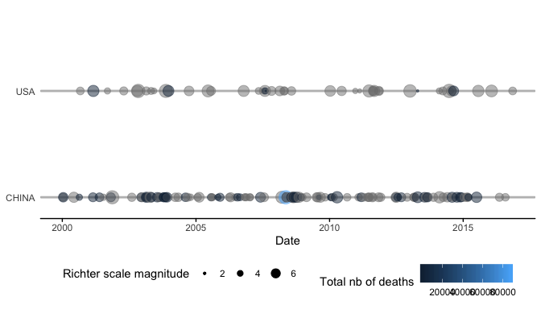

```r
g_usachina <- geom_timeline(noaa_clean,
              mapping = ggplot2::aes(
                y=COUNTRY,
                fill=DEATHS,
                size= MAG
              ),
              countries=c('USA',"China"),
              xmin='2000-01-01',
              xmax='2017-01-01')
g_usachina
```

### Sidenote: Legend labeling with `eq_legend_timeline`

In order to present proper legend label we build function `eq_legend_timeline`.

```r
# define fake aesthetics
feat <- ggplot2::aes(aes_1=DATE,aes_2=MAG,aes_3=DEATHS,aes_4=COUNTRY,aes_5=LOCATION_NAME)
# test eq_legend_timeline in a table
legend_aes <- dplyr::tbl_df(data.frame(
  aesthetic=c('aes_1','aes_2','aes_3','aes_4','aes_5')
)) %>% dplyr::rowwise() %>%
  dplyr::mutate(
    feature= rlang::quo_name(feat[[aesthetic]]),
    label= eq_legend_timeline(feat[[aesthetic]]))
knitr::kable(legend_aes)
```

| aesthetic | feature | label |
| --- | --- | --- |
| aes_1 | DATE | Date |
| aes_2 | MAG | Richter scale magnitude |
| aes_3 | DEATHS | Total nb of deaths |
| aes_4 | COUNTRY | Country |
| aes_5 | LOCATION_NAME | Location_name |

## Adding to timelines locations of most significant earthquakes `geom_timeline_label`

### Adding labels to the previous timeline

The function take `n_max` ads keyword to set the maximum number of locations to display. By default this value is set to 5.

We go back to the first timeline and display the location of the 10 most significant earthquakes

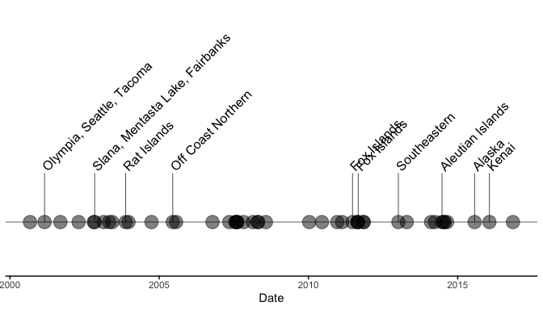

```r
g_usa + geom_timeline_label(n_max=10)
```

We go back to the secondt timeline and display the location of the 5 most significant earthquakes

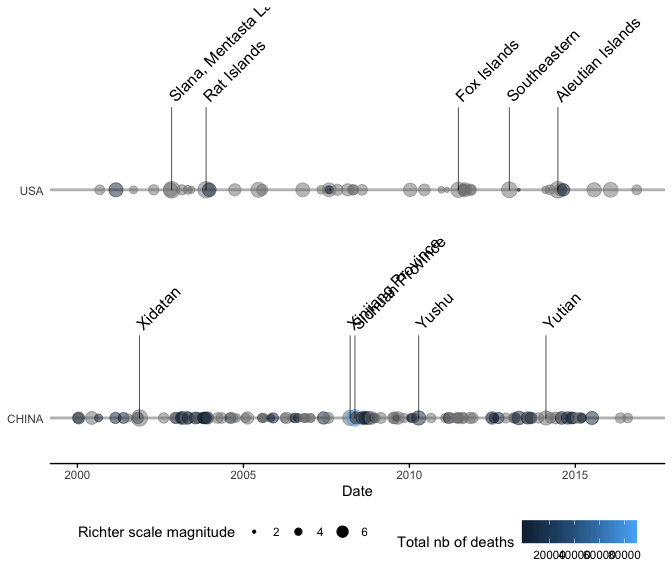

```r
g_usachina + geom_timeline_label()
```

# Building a Map

## Setting a use case

To create a map we have to filter the processed data for a country and specific date range so as to avoid overflowing the visualisation.

```r
filt_noaa <- noaa_clean %>% dplyr::filter(COUNTRY == "MEXICO" & lubridate::year(DATE) >= 2000)
```

## Map with Date popup `eq_map`

Each point correspond to an earthquake with the size of the circle represnting the magnitude.

```r
eq_map(filt_noaa,annot_col = "DATE")
```

[interactive chart not shown]

## Map with annotated popup `eq_map` with `eq_create_label`

Annotation is performed with `eq_create_label`. It simply consists on combining the `LOCATION_NAME`, `DEATHS` and `MAG` feature into a singled html encoded character. As demonstrated in the first 10 rows of our test case.

```r
annot_noaa <- filt_noaa %>% head(10) %>%
  dplyr::mutate(annot_text=eq_create_label(.)) %>%
  dplyr::select("DATE","LOCATION_NAME","DEATHS","MAG","annot_text")
knitr::kable(annot_noaa)
```

| DATE | LOCATION_NAME | DEATHS | MAG | annot_text |
| --- | --- | --- | --- | --- |
| 2002-01-30 | San Andres Tuxtla, Tuxtepec | NA | 5.9 | **Location:** San Andres Tuxtla, Tuxtepec **Magnitude:** 5.9 |
| 2002-02-22 | Mexicali, Baja California | NA | 5.5 | **Location:** Mexicali, Baja California **Magnitude:** 5.5 |
| 2002-09-25 | Acapulco | NA | 5.3 | **Location:** Acapulco **Magnitude:** 5.3 |
| 2003-01-22 | Villa De Alvarez, Colima, Tecoman, Jalisco | 29 | 7.5 | **Location:** Villa De Alvarez, Colima, Tecoman, Jalisco **Magnitude:** 7.5 **Total deaths:** 29 |
| 2004-01-01 | Guerrero, Mexico City | NA | 6.1 | **Location:** Guerrero, Mexico City **Magnitude:** 6.1 |
| 2006-09-10 | Gulf Of Mexico | NA | 5.8 | **Location:** Gulf Of Mexico **Magnitude:** 5.8 |
| 2007-04-13 | Guerrero, Atoyac | NA | 6.0 | **Location:** Guerrero, Atoyac **Magnitude:** 6 |
| 2008-02-09 | Baja California | NA | 5.1 | **Location:** Baja California **Magnitude:** 5.1 |
| 2009-12-30 | Mexicali | NA | 5.9 | **Location:** Mexicali **Magnitude:** 5.9 |
| 2010-04-04 | Baja California | 2 | 7.2 | **Location:** Baja California **Magnitude:** 7.2 **Total deaths:** 2 |

It is call by `eq_map` when option `annot_col` is set to `"popup_test"`, thus giving the following result.

```r
eq_map(filt_noaa,annot_col = "popup_text")
```

[interactive chart not shown]

# Summary

The `NOAAsignifEarthQuakes` performs in a quite straitforward way 3 things

- Read and prepare the raw NOAA data
- Enable the user to expore this date using a efficient timeline visualization
- Enable the user to explore the event location

# Appendix: Raw data codebook

We give a short description of the feature present in the raw data. We indicate the column type as we set it while reading the data.

1. Earthquake Id and type
   - **I_D** : [Character] unique id for the earthquake
   - **FLAG_TSUNAMI** : [Character] Categorical set to **Tsu** if the earthquake generated a Tsunami (set to NA otherwise)
2. Date Time variable
   - **YEAR** : [Integer] 4 digit year corresponding the event, range -2150 to 2018
   - **MONTH** : [Integer] 2 digit month corresponding the event, could be NA
   - **DAY** : [Integer] 2 digit day of the month corresponding to the event
   - **HOUR** : [Integer] 2 digit hour corresponding the event
   - **MINUTE** : [Integer] 2 digit minute corresponding to the event
   - **SECOND** : [Numeric] 2 digit seconds corresponding to the event
3. Earthquake properties
   - **FOCAL_DEPTH** : [Integer] Depth of the earthquake [km] (Valid values: 0 to 700 km)
   - **EQ_PRIMARY** : [Numeric] Equivalent Magnitude, take the value from one of the column below (supposidly only up to one contains a non-missing value)
   - **EQ_MAG_MW** : [Numeric] [Magnitude based on the moments magnitue scale](https://www.ngdc.noaa.gov/nndc/DescribeField.jsp?dataset=101650&s=20&field_name=EQ_MAG_MW) (Valid values: 0.0 to 9.9)
   - **EQ_MAG_MS** : [Numeric] [Surface-wave magnitude](https://www.ngdc.noaa.gov/nndc/DescribeField.jsp?dataset=101650&s=20&field_name=EQ_MAG_MS) (Valid values: 0.0 to 9.9)
   - **EQ_MAG_MB** : [Numeric] [Compressional body wave (P-wave) magnitude](https://www.ngdc.noaa.gov/nndc/DescribeField.jsp?dataset=101650&s=20&field_name=EQ_MAG_MB) (Valid values: 0.0 to 9.9)
   - **EQ_MAG_ML** : [Numeric] [Standard Richter Magintude](https://www.ngdc.noaa.gov/nndc/DescribeField.jsp?dataset=101650&s=20&field_name=EQ_MAG_ML) (Valid values: 0.0 to 9.9)
   - **EQ_MAG_MFA** : [Numeric] [Magnitude estimated for field area, before sesmic instruments were in use](https://www.ngdc.noaa.gov/nndc/DescribeField.jsp?dataset=101650&s=20&field_name=EQ_MAG_MFA) (Valid values: 0.0 to 9.9)
   - **EQ_MAG_UNK** : [Numeric] [Magnitude estimated using and unidentified method](https://www.ngdc.noaa.gov/nndc/DescribeField.jsp?dataset=101650&s=20&field_name=EQ_MAG_UNK) (Valid values: 0.0 to 9.9)
   - **INTENSITY** : [Character] [Modified Mercalli Intensity](https://www.ngdc.noaa.gov/nndc/DescribeField.jsp?dataset=101650&s=20&field_name=INTENSITY) (Valid values: 1 to 12)
4. Location
   - **COUNTRY** : [Character] Country name where the event occured
   - **STATE** : [Character] State where the event occured,
   - **LOCATION_NAME** : [Character] Location name ex: City or geographical landmark
   - **LATITUDE** : [Double] Latitude coordinates of the event
   - **LONGITUDE** : [Double] Longitude coordinates of the event
   - **REGION_CODE** : [Character] Event location, contains country name and locality
5. Death and injuries
   - **DEATHS** : [Integer] Number of deaths
   - **DEATHS_DESCRIPTION** : [Character] Factorial code 1 to 4
   - **MISSING** : [Integer] Number of Missing persons
   - **MISSING_DESCRIPTION** : [Character] Factorial code 1 to 4
   - **INJURIES** : [Integer] Number of injured persons
   - **INJURIES_DESCRIPTION** : [Character] Factorial code 1 to 4
6. Property Damage
   - **DAMAGE_MILLIONS_DOLLARS** : [Numeric] Damage amount in M$
   - **DAMAGE_DESCRIPTION** : [Character] Factorial code 1 to 4
   - **HOUSES_DESTROYED** : [Integer] Number of Houses destroyed
   - **HOUSES_DESTROYED_DESCRIPTION** : [Character] Factorial code 1 to 4
   - **HOUSES_DAMAGED** : [Integer] Number of Houses damaged
   - **HOUSES_DAMAGED_DESCRIPTION** : [Character] Factorial code 1 to 4
7. Total Death and injuries including related events (Tsunami, Volcano etc..)
   - **TOTAL_DEATHS** : [Integer] Number of deaths
   - **TOTAL_DEATHS_DESCRIPTION** : [Character] Factorial code 1 to 4
   - **TOTAL_MISSING** : [Integer] Number of Missing persons
   - **TOTAL_MISSING_DESCRIPTION** : [Character] Factorial code 1 to 4
   - **TOTAL_INJURIES** : [Integer] Number of injured
   - **TOTAL_INJURIES_DESCRIPTION** : [Character] Factorial code 1 to 4
8. Total Property Damage including related events (Tsunami, Volcano etc..)
   - **TOTAL_DAMAGE_MILLIONS_DOLLARS** : [Numeric] Damage amount in M$
   - **TOTAL_DAMAGE_DESCRIPTION** : [Character] Factorial code 1 to 4
   - **TOTAL_HOUSES_DESTROYED** : [Integer] Number of Houses destroyed
   - **TOTAL_HOUSES_DESTROYED_DESCRIPTION** : [Character] Factorial code 1 to 4
   - **TOTAL_HOUSES_DAMAGED** : [Integer] Number of Houses damaged
   - **TOTAL_HOUSES_DAMAGED_DESCRIPTION** : [Character] Factorial code 1 to 4